# MPT & other measurements

# 1 [Modern Portfolio Theory (MPT)](https://www.investopedia.com/walkthrough/fund-guide/introduction/1/modern-portfolio-theory-mpt.aspx#ixzz50Mf3HHix)

# 2 Introduction

The explanations are mostly adapted from investopedia. On the technical side, there are five statistical risk measurements used in modern portfolio theory (MPT);

1. *alpha*
2. *beta*
3. *R-squared*
4. *standard deviation*
5. *Sharpe ratio*.

the former 3 statistical risk measurements used in modern portfolio theory (MPT) will be calculated below, the other 2 will be used in constructing an Efficient Frontier portfolio in another post.

# 3 Packages load

```r
require(PortfolioAnalytics)
require(PerformanceAnalytics)
require(quantmod)
require(zoo)
require(plotly)
require(data.table)
require(DT)
## for optimisation
# library(DEoptim)
# library(ROI)
# require(ROI.plugin.quadprog)
# require(ROI.plugin.glpk)
knitr::opts_chunk$set(results = 'hold', echo = T)
```

# 4 Data Inputs

The inputs column’s indexes, Risk-free bounds, main investments interest and its peers are defined here.

```r
#Defining inputs
# Symbols <- c("^GSPC","XOM","MSFT","JNJ","GE", "^TNX")
Symbols <- c( "^GSPC", "MSFT", "GOOGL", "AAPL",  "AMZN", "FB","^HSI", "^STI", "^TNX")
Returnsxts.col = 1 #Defining main invest
# GSPC/ S&P
Returnsxtspeers.cols = c(2,3,4,5,6,7,8) #Defining peers
#the 5 biggest tech stocks
Returnsxtsindexes.cols = 1  #Defining index
# GSPC/ S&P
Returnsxts.Rf.col = 9  #Defining riskfree invest
# CBOE Interest Rate 10 Year T No (^TNX)
Symbols
```

```
[1] "^GSPC" "MSFT"  "GOOGL" "AAPL"  "AMZN"  "FB"    "^HSI"  "^STI"  "^TNX"
```

# 5 Data input

This section pulls the data, computes its monthly return and assign them appropriately.

```r
# create environment to load data into
Data <- new.env()
getSymbols(Symbols, from="2007-01-01", env=Data)
```

[output not shown]

```
[1] "GSPC"  "MSFT"  "GOOGL" "AAPL"  "AMZN"  "FB"    "HSI"   "STI"   "TNX"
```

```r
# calculate returns, merge, and create data.frame (eapply loops over all
# objects in an environment, applies a function, and returns a list)
ReturnsMonthly <- eapply(Data, function(s) monthlyReturn(Ad(s)))
```

```
missing values removed from datamissing values removed from datamissing values removed from data
```

```r
Returnsxts <- do.call(merge.xts, ReturnsMonthly)
Returnsxts<- na.omit(Returnsxts)
# adjust column names as Symbols
colnames(Returnsxts)<- Symbols
## Depreciated
# ReturnsROC <- eapply(Data, function(s) ROC(Ad(s), type="discrete"))
# ReturnsROC <- eapply(Data, function(s) ROC(Ad(s), n=21))
# ReturnsDF <- as.data.frame(do.call(merge.xts, ReturnsMonthly))
# colnames(ReturnsDF)<- Symbols
##  Defining trailing months
# Often, only recents data hold more signifincat,
# hence, the return data can be filtered to only include a matter of 12 and 36 months worth of data in this case.
#This section define additional trailing parameter
Returnsxts.length = dim(Returnsxts)[1]
# colnames(Returnsxts)
Rxtstrailing12.rows = ((Returnsxts.length - 11):Returnsxts.length)
Rxtstrailing36.rows = ((Returnsxts.length - 35):Returnsxts.length)
```

# 6 Computing Beta, Alpha manually in R

#### 6.0.0.1 Alpha

Alpha is used in finance as a measure of performance. Alpha, often considered the active return on an investment, gauges the performance of an investment against a market index or benchmark which is considered to represent the market’s movement as a whole. The excess return of an investment relative to the return of a benchmark index is the investment’s alpha.

#### 6.0.0.2 Beta

Beta is a measure of the volatility, or systematic risk, of a security or a portfolio in comparison to the market as a whole. Beta is used in the capital asset pricing model (CAPM), which calculates the expected return of an asset based on its beta and expected market returns. Beta is also known as the beta coefficient.

Where,

- $r_F$ risk free rate
- $r_m$ return of the index/market
- $r_a$ expected return of an asset given its risk i
- $\beta_a$ Beta of a security/stocks

Mathematically speaking, Alpha is the rate of return that exceeds a financial expectation. We will use the CAPM formula

$$r-r_f = \beta * (r_m - r_f ) + \alpha$$

```r
#organising the returns by Y and X terms
Y_r <- Returnsxts[, Returnsxtsindexes.cols]- Returnsxts[, Returnsxts.Rf.col]
X_r <- Returnsxts[, Returnsxtspeers.cols]- as.numeric(Returnsxts[, Returnsxts.Rf.col])
#apply lm through different stocks in X_r
lmtable_coef<-data.frame(t(apply(X_r, 2, function(x.col)
  lm(Y_r~x.col )$coef)))
lmtable_rsq<-data.frame((apply(X_r, 2, function(x.col)
  summary(lm(Y_r~x.col ))$r.squared)))
#combining the result
lmtable<- cbind(lmtable_coef, lmtable_rsq)
#cleaning up the table
colnames(lmtable)<-c("Alpha", "Beta", "R-square")
lmtable$Alpha<- round(lmtable$Alpha,3)
lmtable$Beta<- round(lmtable$Beta,3)
lmtable$"R-square"<- round(lmtable$"R-square",3)
#printing the table
datatable(lmtable)
```

|  | Alpha | Beta | R-square |
| --- | --- | --- | --- |
| MSFT | 0.006 | 1.017 | 0.762 |
| GOOGL | -0.004 | 0.871 | 0.651 |
| AAPL | 0.012 | 0.953 | 0.72 |
| AMZN | -0.001 | 0.523 | 0.342 |
| FB | -0.011 | 0.816 | 0.577 |
| ^HSI | -0.003 | 0.81 | 0.685 |
| ^STI | 0.01 | 0.989 | 0.707 |

Other basic plots built in within **PortfolioAnalytics** and **PerformanceAnalytics**

# 7 Basics Histogram plots

Basics Histogram plots are used to verify the distribution, such as how well0 normal distribution describe it and such. Below are plots of **index** (^GSPC) here

```r
layout(rbind(c(1,2),c(3,4)))
chart.Histogram(Returnsxts[,1,drop=F], main = "Plain", methods = NULL)
chart.Histogram(Returnsxts[,1,drop=F], main = "Density", breaks=40,
                methods = c("add.density", "add.normal"))
```

```r
chart.Histogram(Returnsxts[,1,drop=F], main = "Skew and Kurt", methods = c("add.centered", "add.rug"))
chart.Histogram(Returnsxts[,1,drop=F], main = "Risk Measures", methods = c("add.risk"))
```

[figure not shown]

```r
par(mfrow=c(1,1))
```

# 8 Relative return and risk

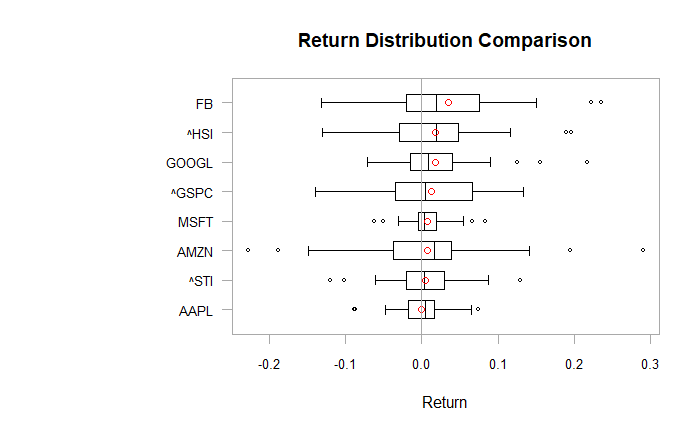

```r
# Plot of Return
chart.Boxplot(Returnsxts[Rxtstrailing36.rows, c(Returnsxts.col, Returnsxtspeers.cols)])
```

# 9 RiskReturn Plot

The plot of the Annualized Return and Risk of various Stocks and index

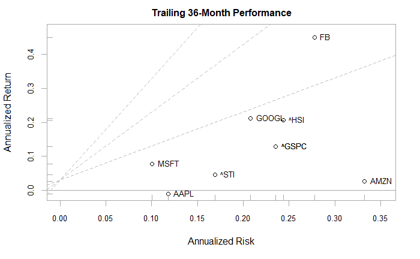

```r
# Plot of RiskReturnScatter
chart.RiskReturnScatter(Returnsxts[ Rxtstrailing36.rows, c(Returnsxts.col, Returnsxtspeers.cols, Returnsxtsindexes.cols)], Rf=.03/12, main = "Trailing 36-Month Performance")
```

# 10 Rolling Performance

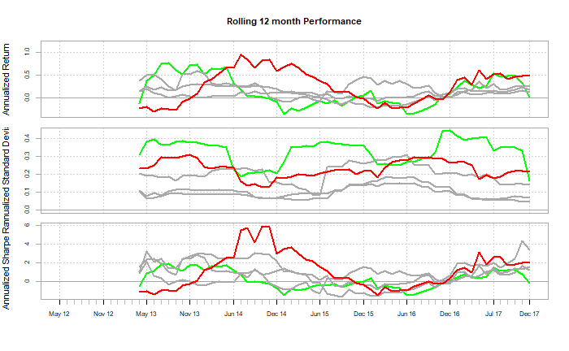

```r
# Examine performance consistency
charts.RollingPerformance(Returnsxts[,c(Returnsxts.col,Returnsxtspeers.cols,Returnsxtsindexes.cols)],
                          Rf=.03/12, colorset = c("red", rep("darkgray",3), "green"), lwd = 2)
```

# 11 Performance Relative to a Benchmark / Relative Performance of Assets

Time Series chart on the ratio of the cumulative performance of various stocks plots relative to index (GSPC).

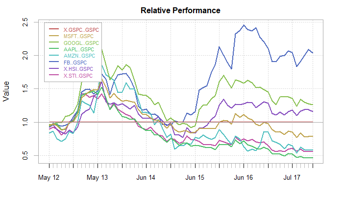

```r
# Examine Performance Relative to a Benchmark
chart.RelativePerformance(Returnsxts[,c(Returnsxts.col,Returnsxtspeers.cols)], Returnsxts[,c(Returnsxtsindexes.cols)], colorset = rainbow8equal, lwd = 2, legend.loc = "topleft")
```

# 12 Rolling Regression Performance

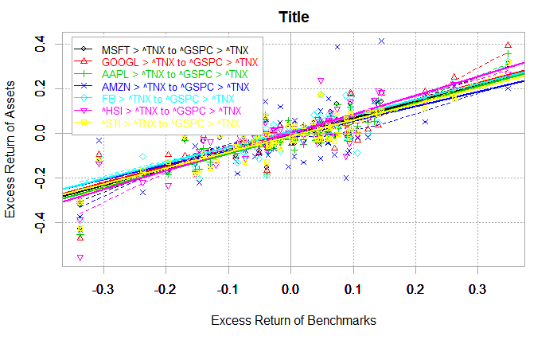

```r
chart.Regression(Returnsxts[, c(Returnsxtspeers.cols), drop = FALSE],
                 Returnsxts[, Returnsxtsindexes.cols, drop = FALSE],
                 Rf = Returnsxts[, Returnsxts.Rf.col, drop = FALSE],
                 excess.returns = TRUE, fit = c("loess", "linear"),
                 legend.loc = "topleft")
```

This depicts the changes in tech stocks’ Alpha, Beta overtime with respect to the index.

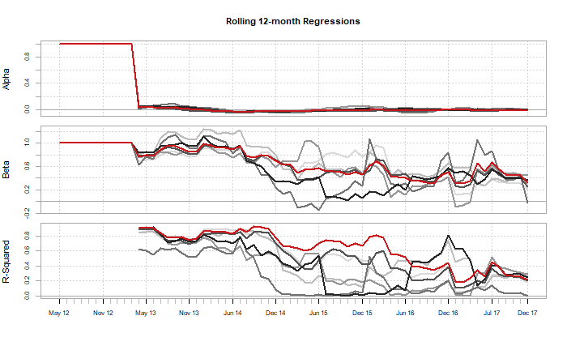

```r
## Create a Rolling Regression
# chart.RollingQuantileRegression(Ra, Rb, width = 12, Rf = 0,
#   attribute = c("Beta", "Alpha", "R-Squared"), main = NULL, na.pad = TRUE,
#   ...)
charts.RollingRegression(Ra = Returnsxts[, c(Returnsxtspeers.cols), drop = FALSE],
                         Rb = Returnsxts[, Returnsxtsindexes.cols, drop = FALSE],
                         Rf = Returnsxts[, Returnsxts.Rf.col, drop = FALSE],
                         colorset = redfocus, lwd = 2)
```

# 13 Rolling Correlation Chart

This depicts the changes of correlation of peers versus index overtime.

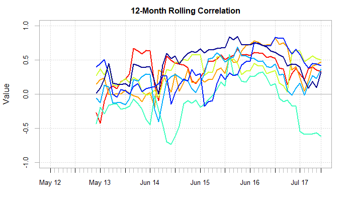

```r
# Chart the Rolling Correlation
chart.RollingCorrelation(Returnsxts[,c(Returnsxtspeers.cols)],
                         Returnsxts[, Returnsxtsindexes.cols, drop = FALSE],
                         colorset = tim8equal, lwd = 2, main = "12-Month Rolling Correlation")
```

# 14 Table

## 14.1 Tables of Returns each years

```r
#Returns a table of returns formatted with years in rows, months in columns, and a total column in the last column. For additional columns in R, annual returns will be appended as columns.
datatable(data.frame(t(table.CalendarReturns(Returnsxts[,c(Returnsxts.col,Returnsxtsindexes.cols)])))
          , options = list(pageLength = 5))
```

```
some row.names duplicated: 14 --> row.names NOT used
```

|  | X2012 | X2013 | X2014 | X2015 | X2016 | X2017 |
| --- | --- | --- | --- | --- | --- | --- |
| 1 |  | -14.4 |  | 6.1 | -7.5 |  |
| 2 |  | -2.5 | 5.8 | 10.1 | -0.1 | 13.4 |
| 3 |  | 0.3 | 2 | -3.1 | 12.7 | 4.9 |
| 4 |  | 0 | 9.9 | 0.6 | -14 | 0 |
| 5 | -1.1 | 2.2 | 7.9 | 4.5 | 7.2 | 6.8 |
| 6 | 1.1 | -11.8 | 2.8 | -3.7 | -4.3 | -5.7 |
| 7 | 4.6 | 14.1 | 2.9 | -3.3 | 9 | 3.3 |
| 8 | 9.4 | 8.4 | 7.8 | -6.6 | 2.4 | 10.7 |
| 9 | 0.3 | -2.1 | -1.7 | -2.2 | 6.6 | -6 |
| 10 | -10.8 | 9.6 | 7.2 | 8.3 | 0.4 | 9.7 |

[output cut: 4 more lines]

```r
#Returns a basic set of statistics that match the period of the data passed in (e.g., monthly returns will get monthly statistics, daily will be daily stats, and so on)
datatable(table.Stats(Returnsxts[,c(Returnsxts.col,Returnsxtspeers.cols)])
          , options = list(pageLength = 5))
```

|  | ^GSPC | MSFT | GOOGL | AAPL | AMZN | FB | ^HSI | ^STI |
| --- | --- | --- | --- | --- | --- | --- | --- | --- |
| Observations | 66 | 66 | 66 | 66 | 66 | 66 | 66 | 66 |
| NAs | 0 | 0 | 0 | 0 | 0 | 0 | 0 | 0 |
| Minimum | -0.1441 | -0.0627 | -0.0983 | -0.088 | -0.2281 | -0.1315 | -0.1302 | -0.1204 |
| Quartile 1 | -0.0218 | -0.0026 | -0.0145 | -0.0148 | -0.0475 | -0.0254 | -0.0178 | -0.0159 |
| Median | 0.0154 | 0.0113 | 0.0117 | 0.0086 | 0.0167 | 0.0211 | 0.0203 | 0.0088 |
| Arithmetic Mean | 0.0158 | 0.0103 | 0.0187 | 0.0025 | 0.0094 | 0.0272 | 0.0176 | 0.0059 |
| Geometric Mean | 0.0135 | 0.01 | 0.0171 | 0.002 | 0.0052 | 0.0245 | 0.0158 | 0.0048 |
| Quartile 3 | 0.0713 | 0.0245 | 0.0541 | 0.0216 | 0.0482 | 0.0739 | 0.0515 | 0.0378 |
| Maximum | 0.1412 | 0.083 | 0.2175 | 0.0743 | 0.2919 | 0.2351 | 0.1963 | 0.1298 |
| SE Mean | 0.0084 | 0.0034 | 0.0072 | 0.0039 | 0.0115 | 0.0092 | 0.0076 | 0.0057 |

[output cut: 6 more lines]

## 14.2 Table of Performance parameter

```r
# Calculate Correlations
datatable(table.Correlation(Returnsxts[, c(Returnsxts.col, Returnsxtspeers.cols)], Returnsxts[, Returnsxtsindexes.cols, drop = F], legend.loc = "lowerleft")
          , options = list(pageLength = 5))
```

|  | Correlation | p-value | Lower CI | Upper CI |
| --- | --- | --- | --- | --- |
| ^GSPC to ^GSPC | 1 | 0 | 1 | 1 |
| MSFT to ^GSPC | 0.442194135650977 | 0.000201328649134537 | 0.224151255888346 | 0.618076933337525 |
| GOOGL to ^GSPC | 0.292037061202217 | 0.0173450918903654 | 0.0538075408464103 | 0.498812500668194 |
| AAPL to ^GSPC | 0.281581030634848 | 0.0219966995390916 | 0.0424406660115173 | 0.490205405304021 |
| AMZN to ^GSPC | -0.121075683375943 | 0.332845453365907 | -0.352770762939578 | 0.124608658084839 |
| FB to ^GSPC | 0.30060301197632 | 0.0141882708421752 | 0.0631659240917034 | 0.505833476426673 |
| ^HSI to ^GSPC | 0.343095203671977 | 0.00479918170795529 | 0.110214688694685 | 0.540264278612956 |
| ^STI to ^GSPC | 0.342416647511483 | 0.00488879243592614 | 0.109455078140933 | 0.53971959297828 |

```r
datatable(table.DownsideRisk(Returnsxts[,c(Returnsxts.col, Returnsxtspeers.cols)],Rf=.03/12)
          , options = list(pageLength = 5))
```

|  | ^GSPC | MSFT | GOOGL | AAPL | AMZN | FB | ^HSI | ^STI |
| --- | --- | --- | --- | --- | --- | --- | --- | --- |
| Semi Deviation | 0.0502 | 0.0202 | 0.0361 | 0.0244 | 0.0625 | 0.0495 | 0.0415 | 0.0341 |
| Gain Deviation | 0.0397 | 0.018 | 0.0487 | 0.0173 | 0.0697 | 0.0546 | 0.0455 | 0.0269 |
| Loss Deviation | 0.0438 | 0.0189 | 0.0265 | 0.0254 | 0.0563 | 0.0338 | 0.0334 | 0.0337 |
| Downside Deviation (MAR=10%) | 0.0462 | 0.0192 | 0.0303 | 0.0274 | 0.0619 | 0.039 | 0.0366 | 0.0354 |
| Downside Deviation (Rf=3%) | 0.0432 | 0.0164 | 0.0273 | 0.0244 | 0.0588 | 0.036 | 0.0337 | 0.0324 |
| Downside Deviation (0%) | 0.042 | 0.0154 | 0.0261 | 0.0232 | 0.0575 | 0.0347 | 0.0325 | 0.0312 |
| Maximum Drawdown | 0.3954 | 0.0889 | 0.1278 | 0.2461 | 0.4646 | 0.1825 | 0.155 | 0.3207 |
| Historical VaR (95%) | -0.1096 | -0.0312 | -0.0599 | -0.0571 | -0.1369 | -0.0831 | -0.0768 | -0.0726 |
| Historical ES (95%) | -0.1281 | -0.0518 | -0.0785 | -0.0762 | -0.185 | -0.0988 | -0.097 | -0.103 |
| Modified VaR (95%) | -0.103 | -0.0366 | -0.0592 | -0.0546 | -0.1281 | -0.0851 | -0.0745 | -0.0737 |

[output cut: 1 more lines]

```r
datatable(table.Drawdowns(Returnsxts[,Returnsxts.col,drop=F])
          , options = list(pageLength = 5))
```

|  | From | Trough | To | Depth | Length | To Trough | Recovery |
| --- | --- | --- | --- | --- | --- | --- | --- |
| 1 | 2012-10-31 | 2013-06-28 | 2014-04-30 | -0.3954 | 18 | 9 | 9 |
| 2 | 2015-06-30 | 2016-04-29 | 2017-02-28 | -0.2702 | 20 | 11 | 9 |
| 3 | 2014-12-31 | 2014-12-31 | 2015-02-27 | -0.0719 | 3 | 1 | 2 |
| 4 | 2017-09-29 | 2017-09-29 | 2017-10-31 | -0.0602 | 2 | 1 | 1 |
| 5 | 2017-06-30 | 2017-06-30 | 2017-08-31 | -0.0572 | 3 | 1 | 2 |